# Лабораторная 6. Экспоненциальное сглаживание

## 14. Когда ETS выбирает плохо

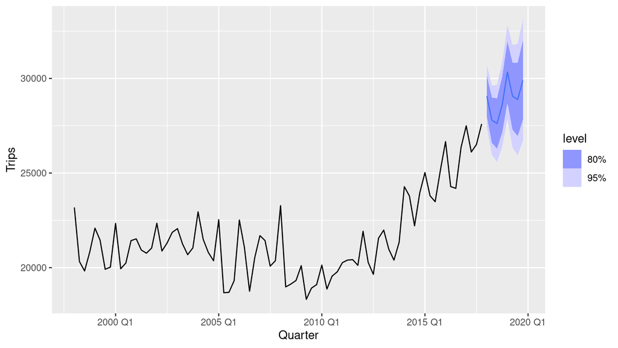

```r
trips |>
  model(ETS(Trips)) |>
  forecast(h = 8) |>
  autoplot(trips)
```

```r
stocks <- gafa_stock |>
  as_tibble() |>
  group_by(Symbol) |>
  mutate(day = row_number()) |>
  ungroup() |>
  as_tsibble(index = day, key = Symbol, regular = TRUE)
fit_stocks <- stocks |> model(ETS(Close))
report(fit_stocks)
```

```
## # A tibble: 4 × 10
##   Symbol .model       sigma2 log_lik    AIC   AICc    BIC    MSE   AMSE    MAE
##   <chr>  <chr>         <dbl>   <dbl>  <dbl>  <dbl>  <dbl>  <dbl>  <dbl>  <dbl>
## 1 AAPL   ETS(Close) 0.000228  -5299. 10604. 10604. 10620.   4.39   8.96 0.0106
## 2 AMZN   ETS(Close) 0.000383  -7778. 15561. 15561. 15577. 359.   700.   0.0129
## 3 FB     ETS(Close) 0.000356  -5442. 10890. 10890. 10906.   5.82  11.3  0.0126
## 4 GOOG   ETS(Close) 0.000219  -7529. 15064. 15064. 15079. 144.   291.   0.0102
```

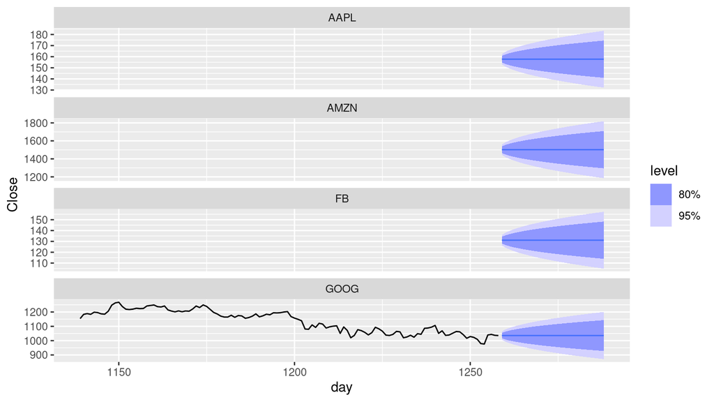

```r
autoplot(forecast(fit_stocks, h = 30), stocks |> slice_tail(n = 120))
```

```r
lynx <- pelt |> select(Lynx)
fit_lynx <- lynx |> model(ETS(Lynx))
report(fit_lynx)
```

```
## Series: Lynx
## Model: ETS(A,N,N)
##   Smoothing parameters:
##     alpha = 0.9998998
##
##   Initial states:
##      l[0]
##  25737.12
##
##   sigma^2:  162584145
##
##      AIC     AICc      BIC
## 2134.976 2135.252 2142.509
```

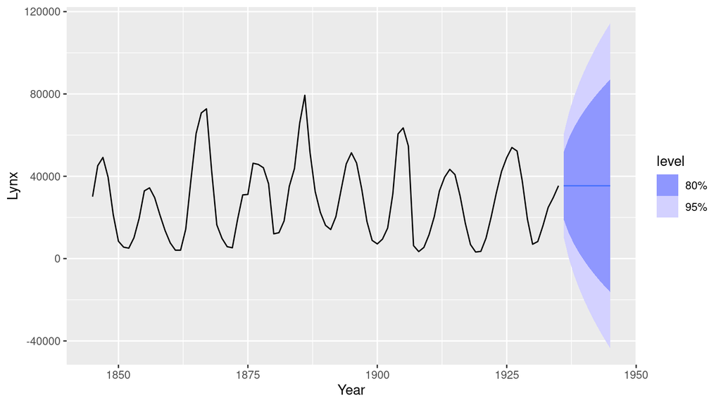

```r
autoplot(forecast(fit_lynx, h = 10), lynx)
```

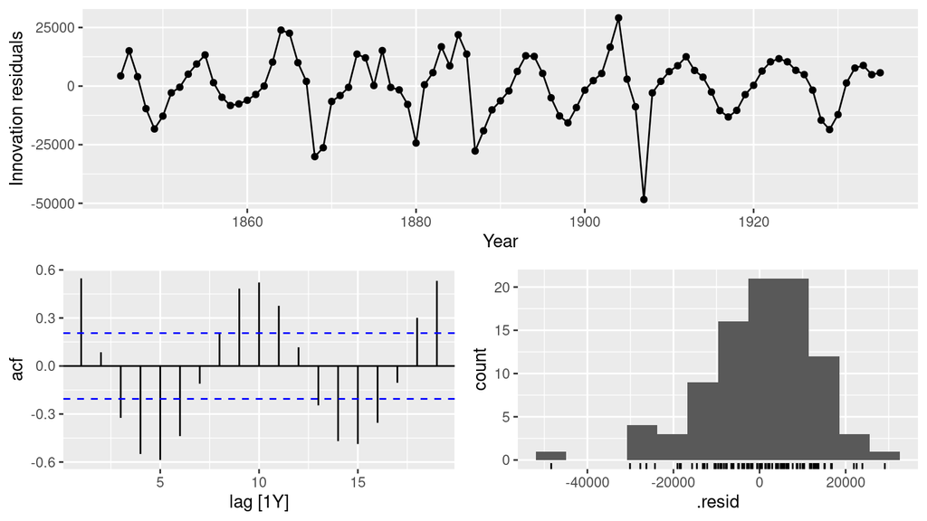

```r
gg_tsresiduals(fit_lynx)
```

На сумме поездок ETS уместен: есть сезон и тренд, которые экспоненциальное сглаживание умеет. На ценах акций ETS либо рисует дрейф, либо плоский уровень. Цикла и смены режима там нет, прогноз — прямая, а цена так не продолжится. Рысь — цикл около 10 лет. Годовой ETS без сезона (сезона длины 1 нет) не умеет цикл: прогноз затухает к среднему или к прямой, а остатки остаются циклическими. ETS здесь плох, потому что в семействе нет циклической компоненты, только уровень, тренд и календарный сезон.